# IS607FinalProject

# ————————————————————————

# Predicting Pass and Fail using G1 + G2 using DecisionTree

# ————————————————————————

```r
formula <- Pass ~ G1 + G2
tree <- ctree(formula, data=students)

print(tree)
```

```
##
##   Conditional inference tree with 4 terminal nodes
##
## Response:  Pass
## Inputs:  G1, G2
## Number of observations:  349
##
## 1) G2 <= 9; criterion = 1, statistic = 179.794
##   2) G2 <= 8; criterion = 0.999, statistic = 11.579
##     3)*  weights = 82
##   2) G2 > 8
##     4)*  weights = 44
## 1) G2 > 9
##   5) G1 <= 10; criterion = 0.999, statistic = 12.194
##     6)*  weights = 51
##   5) G1 > 10
##     7)*  weights = 172
```

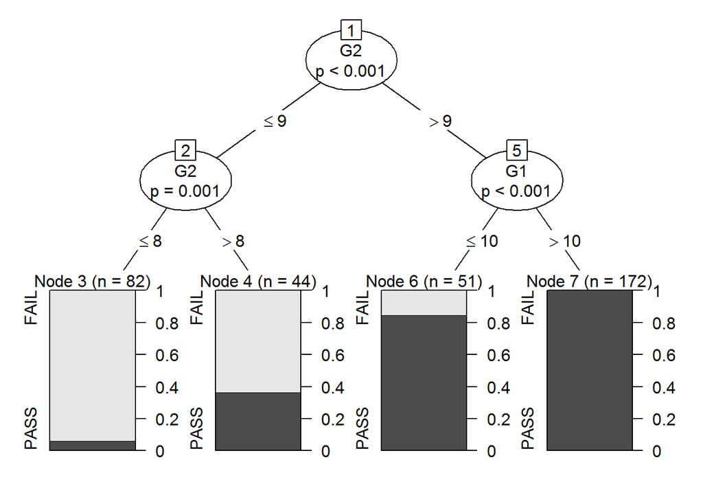

```r
plot(tree)
```

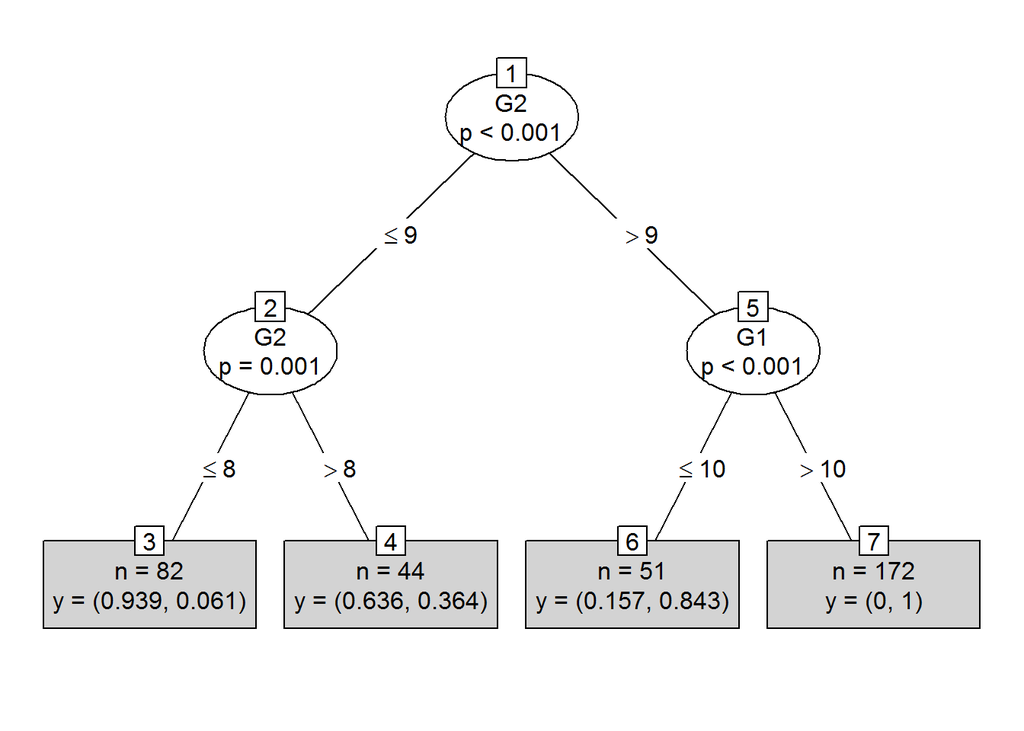

```r
plot(tree, type="simple")
```

```r
sprintf('Errors-on-predictions Matrix')
```

```
## [1] "Errors-on-predictions Matrix"
```

```r
table(predict(tree, newdata=students), students$Pass,dnn=c('Predicted','Actual'))
```

```
##          Actual
## Predicted FAIL PASS
##      FAIL  105   21
##      PASS    8  215
```

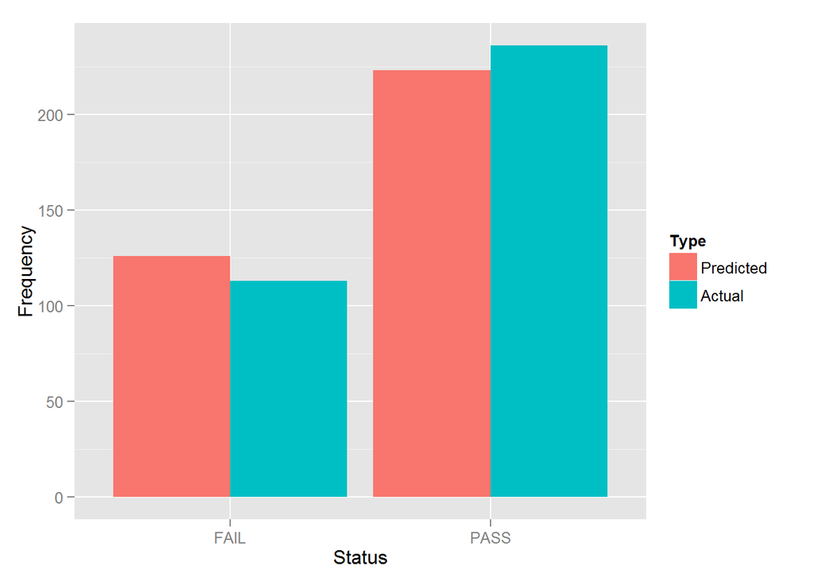

```r
df.confmatrix <- data.frame(table(predict(tree, newdata=students), students$Pass,dnn=c('Predicted','Actual')))


data_long <- gather(df.confmatrix, Type, Status, Predicted:Actual)
data_long <- data_long %>% group_by(Status,Type) %>% summarise(Frequency=sum(Freq))
ggplot(data_long, aes(x=Status,y=Frequency,fill=Type)) + geom_bar(stat='identity', position='dodge')
```

# ————————————————————————

# Predicting Grades using G1 + G2 using DecisionTree

# ————————————————————————

```r
formula <- Grade ~ G1 + G2
tree <- ctree(formula, data=students)

print(tree)
```

```
##
##   Conditional inference tree with 8 terminal nodes
##
## Response:  Grade
## Inputs:  G1, G2
## Number of observations:  349
##
## 1) G2 <= 9; criterion = 1, statistic = 267.241
##   2) G2 <= 8; criterion = 0.999, statistic = 11.579
##     3)*  weights = 82
##   2) G2 > 8
##     4)*  weights = 44
## 1) G2 > 9
##   5) G2 <= 15; criterion = 1, statistic = 185.971
##     6) G2 <= 11; criterion = 1, statistic = 151.247
##       7)*  weights = 72
##     6) G2 > 11
##       8) G2 <= 13; criterion = 1, statistic = 77.643
##         9) G2 <= 12; criterion = 0.998, statistic = 14.374
##           10)*  weights = 36
##         9) G2 > 12
##           11)*  weights = 32
##       8) G2 > 13
##         12) G2 <= 14; criterion = 0.993, statistic = 11.398
##           13)*  weights = 21
##         12) G2 > 14
##           14)*  weights = 32
##   5) G2 > 15
##     15)*  weights = 30
```

[figure not shown]

```r
plot(tree)
```

[figure not shown]

```r
plot(tree, type="simple")
```

```r
sprintf('Errors-on-predictions Matrix')
```

```
## [1] "Errors-on-predictions Matrix"
```

```r
table(predict(tree, newdata=students), students$Grade,dnn=c('Predicted','Actual'))
```

```
##               Actual
## Predicted      FAIL Sufficient Satisfactory Good Excellent
##   FAIL          105         21            0    0         0
##   Sufficient      8         56            8    0         0
##   Satisfactory    0         12           43   13         0
##   Good            0          0            3   40        10
##   Excellent       0          0            0    3        27
```

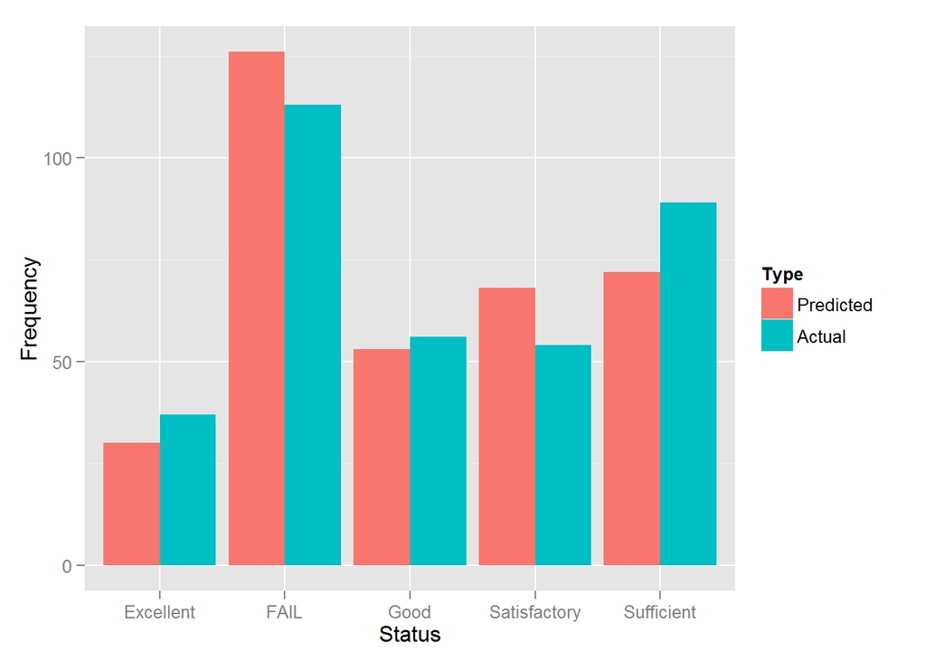

```r
df.confmatrix <- data.frame(table(predict(tree, newdata=students), students$Grade,dnn=c('Predicted','Actual')))


data_long <- gather(df.confmatrix, Type, Status, Predicted:Actual)
data_long <- data_long %>% group_by(Status,Type) %>% summarise(Frequency=sum(Freq))
ggplot(data_long, aes(x=Status,y=Frequency,fill=Type)) + geom_bar(stat='identity', position='dodge')
```

# ————————————————————————

# Predicting Pass and Fail using Naive Bayes Prediction

# ————————————————————————

```r
classifier<-naiveBayes(students[,1:4], students[,8])


#table(predict(classifier, students[,1:4]), students[,8], dnn = c('Predicted','Actual'))


sprintf('Errors-on-predictions Matrix')
```

```
## [1] "Errors-on-predictions Matrix"
```

```r
table(predict(classifier, students[,1:4]), students[,8], dnn = c('Predicted','Actual'))
```

```
##          Actual
## Predicted FAIL PASS
##      FAIL    8    9
##      PASS  105  227
```

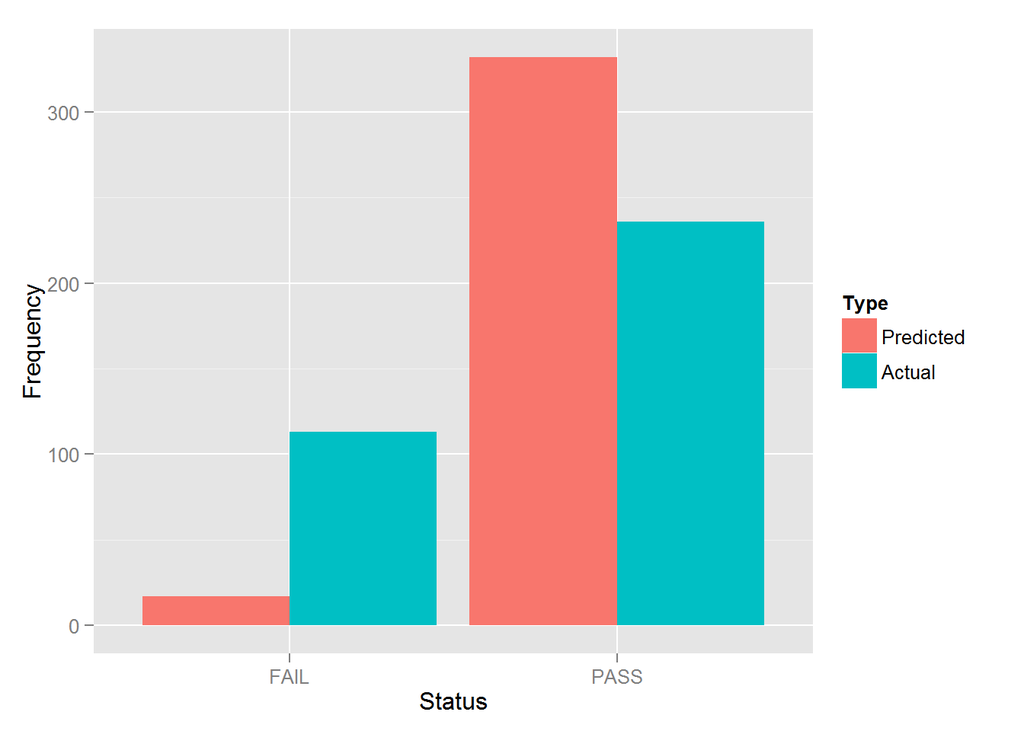

```r
df.confmatrix <- data.frame(table(predict(classifier, students[,1:4]), students[,8], dnn = c('Predicted','Actual')))

data_long <- gather(df.confmatrix, Type, Status, Predicted:Actual)
data_long <- data_long %>% group_by(Status,Type) %>% summarise(Frequency=sum(Freq))
ggplot(data_long, aes(x=Status,y=Frequency,fill=Type)) + geom_bar(stat='identity', position='dodge')
```

# ————————————————————————

# Predicting Grades using Naive Bayes Prediction

# ————————————————————————

```r
classifier<-naiveBayes(students[,1:4], students[,9])



sprintf('Errors-on-predictions Matrix')
```

```
## [1] "Errors-on-predictions Matrix"
```

```r
table(predict(classifier, students[,1:4]), students[,9], dnn = c('Predicted','Actual'))
```

```
##               Actual
## Predicted      FAIL Sufficient Satisfactory Good Excellent
##   FAIL           87         49           39   33        20
##   Sufficient     14         28            9    4         5
##   Satisfactory    0          0            0    0         0
##   Good           11         11            6   17        11
##   Excellent       1          1            0    2         1
```

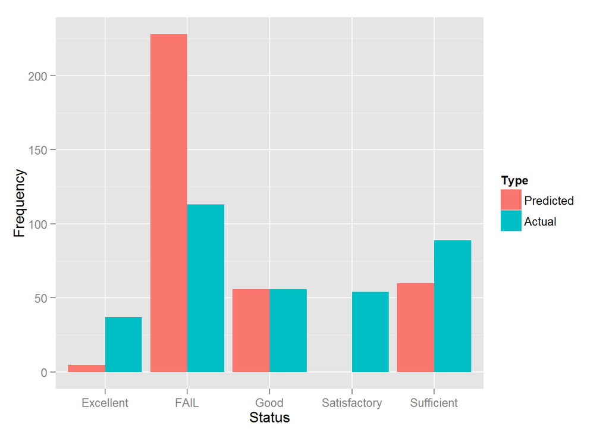

```r
df.confmatrix <- data.frame(table(predict(classifier, students[,1:4]), students[,9], dnn = c('Predicted','Actual')))

data_long <- gather(df.confmatrix, Type, Status, Predicted:Actual)
data_long <- data_long %>% group_by(Status,Type) %>% summarise(Frequency=sum(Freq))
ggplot(data_long, aes(x=Status,y=Frequency,fill=Type)) + geom_bar(stat='identity', position='dodge')
```

# ————————————————————————

# ————————————————————————

## Linear regression showed strong relationship between G3 and G2. G1 also showed positive relationship but not as strong as G2.

## Decision tree prediction on the same dataset showed very less errors on predictions making G1 and G2 suitable for predicting Grades and Pass-ability of students

## Naive Bayes method showed large errors on predictions. So, either the those four variables are not good predictors or Naive Bayes method is not a good predicting model for this dataset.

## Based on all the analysis, G2 is the strongest predictor for G3, which in turn, for pass-ability and grades.